# Risk Factor Analysis

## Outcome Variable

**Outcome Variable:** whz

## Predictor Variables

**Intervention Variable:** mhtcm

**Adjustment Set:**

- arm
- W_mage
- meducyrs
- feducyrs
- single
- delta_W_mage
- delta_meducyrs
- delta_feducyrs
- delta_single

## Stratifying Variables

The analysis was stratified on these variable(s):

- agecat
- studyid
- country

## Data Summary

| agecat | studyid | country | mhtcm | n_cell | n |
| --- | --- | --- | --- | --- | --- |
| Birth | ki0047075b-MAL-ED | BANGLADESH | >=155 cm | 24 | 233 |
| Birth | ki0047075b-MAL-ED | BANGLADESH | <151 cm | 145 | 233 |
| Birth | ki0047075b-MAL-ED | BANGLADESH | [151-155) cm | 64 | 233 |
| Birth | ki0047075b-MAL-ED | BRAZIL | >=155 cm | 105 | 176 |
| Birth | ki0047075b-MAL-ED | BRAZIL | <151 cm | 46 | 176 |
| Birth | ki0047075b-MAL-ED | BRAZIL | [151-155) cm | 25 | 176 |
| Birth | ki0047075b-MAL-ED | INDIA | >=155 cm | 45 | 195 |
| Birth | ki0047075b-MAL-ED | INDIA | <151 cm | 94 | 195 |
| Birth | ki0047075b-MAL-ED | INDIA | [151-155) cm | 56 | 195 |
| Birth | ki0047075b-MAL-ED | NEPAL | >=155 cm | 27 | 167 |
| Birth | ki0047075b-MAL-ED | NEPAL | <151 cm | 93 | 167 |
| Birth | ki0047075b-MAL-ED | NEPAL | [151-155) cm | 47 | 167 |
| Birth | ki0047075b-MAL-ED | PERU | >=155 cm | 56 | 269 |
| Birth | ki0047075b-MAL-ED | PERU | <151 cm | 156 | 269 |
| Birth | ki0047075b-MAL-ED | PERU | [151-155) cm | 57 | 269 |
| Birth | ki0047075b-MAL-ED | SOUTH AFRICA | >=155 cm | 172 | 226 |
| Birth | ki0047075b-MAL-ED | SOUTH AFRICA | <151 cm | 28 | 226 |
| Birth | ki0047075b-MAL-ED | SOUTH AFRICA | [151-155) cm | 26 | 226 |
| Birth | ki0047075b-MAL-ED | TANZANIA, UNITED REPUBLIC OF | >=155 cm | 74 | 116 |
| Birth | ki0047075b-MAL-ED | TANZANIA, UNITED REPUBLIC OF | <151 cm | 19 | 116 |
| Birth | ki0047075b-MAL-ED | TANZANIA, UNITED REPUBLIC OF | [151-155) cm | 23 | 116 |
| Birth | ki1000304b-SAS-CompFeed | INDIA | >=155 cm | 52 | 110 |
| Birth | ki1000304b-SAS-CompFeed | INDIA | <151 cm | 28 | 110 |
| Birth | ki1000304b-SAS-CompFeed | INDIA | [151-155) cm | 30 | 110 |
| Birth | ki1017093-NIH-Birth | BANGLADESH | >=155 cm | 7 | 28 |
| Birth | ki1017093-NIH-Birth | BANGLADESH | <151 cm | 15 | 28 |
| Birth | ki1017093-NIH-Birth | BANGLADESH | [151-155) cm | 6 | 28 |
| Birth | ki1017093c-NIH-Crypto | BANGLADESH | >=155 cm | 4 | 23 |
| Birth | ki1017093c-NIH-Crypto | BANGLADESH | <151 cm | 15 | 23 |
| Birth | ki1017093c-NIH-Crypto | BANGLADESH | [151-155) cm | 4 | 23 |

[output cut: 144 more lines]

The following strata were considered:

- agecat: 24 months, studyid: ki0047075b-MAL-ED, country: BANGLADESH
- agecat: 24 months, studyid: ki0047075b-MAL-ED, country: BRAZIL
- agecat: 24 months, studyid: ki0047075b-MAL-ED, country: INDIA
- agecat: 24 months, studyid: ki0047075b-MAL-ED, country: NEPAL
- agecat: 24 months, studyid: ki0047075b-MAL-ED, country: PERU
- agecat: 24 months, studyid: ki0047075b-MAL-ED, country: SOUTH AFRICA
- agecat: 24 months, studyid: ki0047075b-MAL-ED, country: TANZANIA, UNITED REPUBLIC OF
- agecat: 24 months, studyid: ki1017093-NIH-Birth, country: BANGLADESH
- agecat: 24 months, studyid: ki1017093b-PROVIDE, country: BANGLADESH
- agecat: 24 months, studyid: ki1017093c-NIH-Crypto, country: BANGLADESH
- agecat: 24 months, studyid: ki1066203-TanzaniaChild2, country: TANZANIA, UNITED REPUBLIC OF
- agecat: 24 months, studyid: ki1101329-Keneba, country: GAMBIA
- agecat: 24 months, studyid: ki1119695-PROBIT, country: BELARUS
- agecat: 24 months, studyid: ki1126311-ZVITAMBO, country: ZIMBABWE
- agecat: 24 months, studyid: ki1135781-COHORTS, country: GUATEMALA
- agecat: 24 months, studyid: ki1135781-COHORTS, country: INDIA
- agecat: 24 months, studyid: ki1135781-COHORTS, country: PHILIPPINES
- agecat: 24 months, studyid: ki1148112-LCNI-5, country: MALAWI
- agecat: 24 months, studyid: kiGH5241-JiVitA-3, country: BANGLADESH
- agecat: 6 months, studyid: ki0047075b-MAL-ED, country: BANGLADESH
- agecat: 6 months, studyid: ki0047075b-MAL-ED, country: BRAZIL
- agecat: 6 months, studyid: ki0047075b-MAL-ED, country: INDIA
- agecat: 6 months, studyid: ki0047075b-MAL-ED, country: NEPAL
- agecat: 6 months, studyid: ki0047075b-MAL-ED, country: PERU
- agecat: 6 months, studyid: ki0047075b-MAL-ED, country: SOUTH AFRICA
- agecat: 6 months, studyid: ki0047075b-MAL-ED, country: TANZANIA, UNITED REPUBLIC OF
- agecat: 6 months, studyid: ki1000304b-SAS-CompFeed, country: INDIA
- agecat: 6 months, studyid: ki1000304b-SAS-FoodSuppl, country: INDIA
- agecat: 6 months, studyid: ki1017093-NIH-Birth, country: BANGLADESH
- agecat: 6 months, studyid: ki1017093b-PROVIDE, country: BANGLADESH
- agecat: 6 months, studyid: ki1017093c-NIH-Crypto, country: BANGLADESH
- agecat: 6 months, studyid: ki1066203-TanzaniaChild2, country: TANZANIA, UNITED REPUBLIC OF
- agecat: 6 months, studyid: ki1101329-Keneba, country: GAMBIA
- agecat: 6 months, studyid: ki1112895-Guatemala BSC, country: GUATEMALA
- agecat: 6 months, studyid: ki1119695-PROBIT, country: BELARUS
- agecat: 6 months, studyid: ki1126311-ZVITAMBO, country: ZIMBABWE
- agecat: 6 months, studyid: ki1135781-COHORTS, country: GUATEMALA
- agecat: 6 months, studyid: ki1135781-COHORTS, country: INDIA
- agecat: 6 months, studyid: ki1135781-COHORTS, country: PHILIPPINES
- agecat: 6 months, studyid: ki1148112-LCNI-5, country: MALAWI
- agecat: 6 months, studyid: kiGH5241-JiVitA-3, country: BANGLADESH
- agecat: Birth, studyid: ki0047075b-MAL-ED, country: BANGLADESH
- agecat: Birth, studyid: ki0047075b-MAL-ED, country: BRAZIL
- agecat: Birth, studyid: ki0047075b-MAL-ED, country: INDIA
- agecat: Birth, studyid: ki0047075b-MAL-ED, country: NEPAL
- agecat: Birth, studyid: ki0047075b-MAL-ED, country: PERU
- agecat: Birth, studyid: ki0047075b-MAL-ED, country: SOUTH AFRICA
- agecat: Birth, studyid: ki0047075b-MAL-ED, country: TANZANIA, UNITED REPUBLIC OF
- agecat: Birth, studyid: ki1000304b-SAS-CompFeed, country: INDIA
- agecat: Birth, studyid: ki1017093-NIH-Birth, country: BANGLADESH
- agecat: Birth, studyid: ki1017093c-NIH-Crypto, country: BANGLADESH
- agecat: Birth, studyid: ki1101329-Keneba, country: GAMBIA
- agecat: Birth, studyid: ki1119695-PROBIT, country: BELARUS
- agecat: Birth, studyid: ki1126311-ZVITAMBO, country: ZIMBABWE
- agecat: Birth, studyid: ki1135781-COHORTS, country: GUATEMALA
- agecat: Birth, studyid: ki1135781-COHORTS, country: INDIA
- agecat: Birth, studyid: ki1135781-COHORTS, country: PHILIPPINES
- agecat: Birth, studyid: kiGH5241-JiVitA-3, country: BANGLADESH

### Dropped Strata

Some strata were dropped due to rare outcomes:

- agecat: Birth, studyid: ki1017093c-NIH-Crypto, country: BANGLADESH
- agecat: 24 months, studyid: ki1066203-TanzaniaChild2, country: TANZANIA, UNITED REPUBLIC OF

## Methods Detail

We’re interested in the causal parameters $E[Y_a]$ for all values of $a \in \mathcal{A}$. These parameters represent the mean outcome if, possibly contrary to fact, we intervened to set all units to have $A=a$. Under the randomization and positivity assumptions, these are identified by the statistical parameters $\psi_a=E_W[E_{Y|A,W}(Y|A=a,W)]$. In addition, we’re interested in the mean of $Y$, $E[Y]$ under no intervention (the observed mean). We will estimate these parameters by using SuperLearner to fit the relevant likelihood factors – $E_{Y|A,W}(Y|A=a,W)$ and $p(A=a|W)$, and then updating our likelihood fit using a joint TMLE.

For unadjusted analyses ($W=\{\}$), initial likelihoods were estimated using Lrnr_glm to estimate the simple $E(Y|A)$ and Lrnr_mean to estimate $p(A)$. For adjusted analyses, a small library containing Lrnr_glmnet, Lrnr_xgboost, and Lrnr_mean was used.

Having estimated these parameters, we will then use the delta method to estimate relative risks and attributable risks relative to a prespecified baseline level of $A$.

# Results Detail

## Results Plots

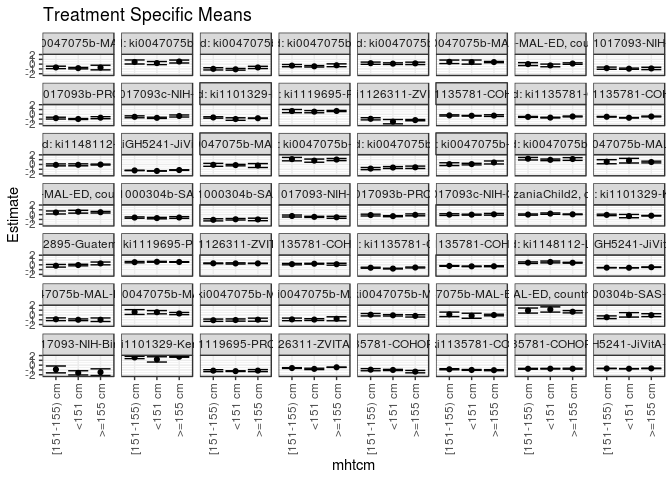

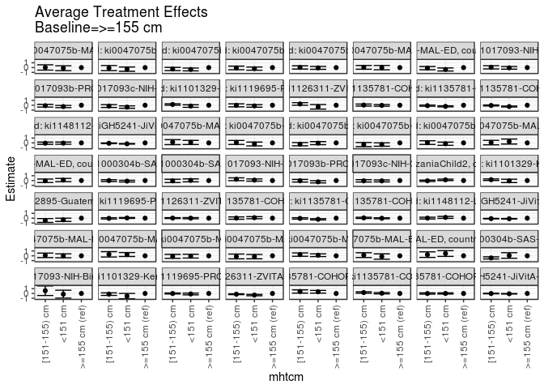

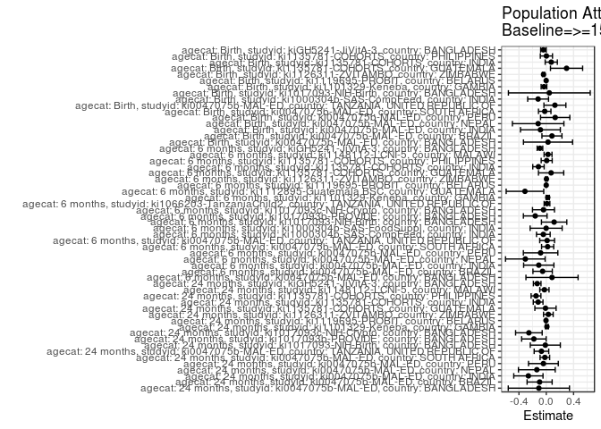

## Results Table

### Parameter: TSM

| agecat | studyid | country | intervention_level | baseline_level | estimate | ci_lower | ci_upper |
| --- | --- | --- | --- | --- | --- | --- | --- |
| Birth | ki0047075b-MAL-ED | BANGLADESH | >=155 cm | NA | -0.9983456 | -1.3663876 | -0.6303036 |
| Birth | ki0047075b-MAL-ED | BANGLADESH | <151 cm | NA | -1.0003108 | -1.1762241 | -0.8243974 |
| Birth | ki0047075b-MAL-ED | BANGLADESH | [151-155) cm | NA | -0.8982099 | -1.1836708 | -0.6127490 |
| Birth | ki0047075b-MAL-ED | BRAZIL | >=155 cm | NA | 0.3000437 | 0.0690109 | 0.5310766 |
| Birth | ki0047075b-MAL-ED | BRAZIL | <151 cm | NA | 0.5713397 | 0.2353388 | 0.9073406 |
| Birth | ki0047075b-MAL-ED | BRAZIL | [151-155) cm | NA | 0.6099597 | 0.1071642 | 1.1127552 |
| Birth | ki0047075b-MAL-ED | INDIA | >=155 cm | NA | -0.9841471 | -1.3049788 | -0.6633154 |
| Birth | ki0047075b-MAL-ED | INDIA | <151 cm | NA | -1.0556468 | -1.2841671 | -0.8271265 |
| Birth | ki0047075b-MAL-ED | INDIA | [151-155) cm | NA | -1.0953490 | -1.3347169 | -0.8559811 |
| Birth | ki0047075b-MAL-ED | NEPAL | >=155 cm | NA | -0.7939057 | -1.2051993 | -0.3826120 |
| Birth | ki0047075b-MAL-ED | NEPAL | <151 cm | NA | -0.9603148 | -1.1455835 | -0.7750461 |
| Birth | ki0047075b-MAL-ED | NEPAL | [151-155) cm | NA | -0.9222061 | -1.1923420 | -0.6520702 |
| Birth | ki0047075b-MAL-ED | PERU | >=155 cm | NA | -0.1968186 | -0.4316742 | 0.0380370 |
| Birth | ki0047075b-MAL-ED | PERU | <151 cm | NA | -0.0721544 | -0.2243354 | 0.0800266 |
| Birth | ki0047075b-MAL-ED | PERU | [151-155) cm | NA | 0.0533834 | -0.2022125 | 0.3089793 |
| Birth | ki0047075b-MAL-ED | SOUTH AFRICA | >=155 cm | NA | -0.0119311 | -0.1757844 | 0.1519222 |
| Birth | ki0047075b-MAL-ED | SOUTH AFRICA | <151 cm | NA | -0.1612573 | -0.6867473 | 0.3642327 |
| Birth | ki0047075b-MAL-ED | SOUTH AFRICA | [151-155) cm | NA | 0.1281922 | -0.3402984 | 0.5966829 |
| Birth | ki0047075b-MAL-ED | TANZANIA, UNITED REPUBLIC OF | >=155 cm | NA | 0.6683337 | 0.4267853 | 0.9098821 |
| Birth | ki0047075b-MAL-ED | TANZANIA, UNITED REPUBLIC OF | <151 cm | NA | 1.1435271 | 0.5978815 | 1.6891728 |
| Birth | ki0047075b-MAL-ED | TANZANIA, UNITED REPUBLIC OF | [151-155) cm | NA | 0.9133365 | 0.3856999 | 1.4409730 |
| Birth | ki1000304b-SAS-CompFeed | INDIA | >=155 cm | NA | -0.0406471 | -0.3447991 | 0.2635049 |
| Birth | ki1000304b-SAS-CompFeed | INDIA | <151 cm | NA | 0.0261986 | -0.4371760 | 0.4895732 |
| Birth | ki1000304b-SAS-CompFeed | INDIA | [151-155) cm | NA | -0.4778296 | -0.7580264 | -0.1976327 |
| Birth | ki1017093-NIH-Birth | BANGLADESH | >=155 cm | NA | -1.4685714 | -2.1619946 | -0.7751483 |
| Birth | ki1017093-NIH-Birth | BANGLADESH | <151 cm | NA | -1.6133333 | -2.0477055 | -1.1789612 |
| Birth | ki1017093-NIH-Birth | BANGLADESH | [151-155) cm | NA | -0.8983333 | -1.6138650 | -0.1828017 |
| Birth | ki1101329-Keneba | GAMBIA | >=155 cm | NA | 1.7437033 | 1.6520819 | 1.8353247 |
| Birth | ki1101329-Keneba | GAMBIA | <151 cm | NA | 1.1931747 | 0.6457106 | 1.7406387 |
| Birth | ki1101329-Keneba | GAMBIA | [151-155) cm | NA | 1.6014623 | 1.3540534 | 1.8488713 |

[output cut: 138 more lines]

### Parameter: E(Y)

| agecat | studyid | country | intervention_level | baseline_level | estimate | ci_lower | ci_upper |
| --- | --- | --- | --- | --- | --- | --- | --- |
| Birth | ki0047075b-MAL-ED | BANGLADESH | NA | NA | -0.9724464 | -1.1091046 | -0.8357881 |
| Birth | ki0047075b-MAL-ED | BRAZIL | NA | NA | 0.3832386 | 0.2044597 | 0.5620175 |
| Birth | ki0047075b-MAL-ED | INDIA | NA | NA | -1.0698974 | -1.2115847 | -0.9282102 |
| Birth | ki0047075b-MAL-ED | NEPAL | NA | NA | -0.9126946 | -1.0520834 | -0.7733058 |
| Birth | ki0047075b-MAL-ED | PERU | NA | NA | -0.0660967 | -0.1789362 | 0.0467429 |
| Birth | ki0047075b-MAL-ED | SOUTH AFRICA | NA | NA | -0.0346018 | -0.1831486 | 0.1139451 |
| Birth | ki0047075b-MAL-ED | TANZANIA, UNITED REPUBLIC OF | NA | NA | 0.7950000 | 0.5947353 | 0.9952647 |
| Birth | ki1000304b-SAS-CompFeed | INDIA | NA | NA | -0.1601818 | -0.3763991 | 0.0560355 |
| Birth | ki1017093-NIH-Birth | BANGLADESH | NA | NA | -1.4239286 | -1.7688028 | -1.0790544 |
| Birth | ki1101329-Keneba | GAMBIA | NA | NA | 1.7101663 | 1.6251406 | 1.7951919 |
| Birth | ki1119695-PROBIT | BELARUS | NA | NA | -1.1440966 | -1.3546950 | -0.9334981 |
| Birth | ki1126311-ZVITAMBO | ZIMBABWE | NA | NA | -0.4901203 | -0.5209592 | -0.4592815 |
| Birth | ki1135781-COHORTS | GUATEMALA | NA | NA | -1.0617914 | -1.1634113 | -0.9601716 |
| Birth | ki1135781-COHORTS | INDIA | NA | NA | -0.9773926 | -1.0345102 | -0.9202750 |
| Birth | ki1135781-COHORTS | PHILIPPINES | NA | NA | -0.7427251 | -0.7890855 | -0.6963647 |
| Birth | kiGH5241-JiVitA-3 | BANGLADESH | NA | NA | -0.7243418 | -0.7441385 | -0.7045450 |
| 6 months | ki0047075b-MAL-ED | BANGLADESH | NA | NA | -0.1397960 | -0.2688682 | -0.0107238 |
| 6 months | ki0047075b-MAL-ED | BRAZIL | NA | NA | 0.9717225 | 0.8073791 | 1.1360658 |
| 6 months | ki0047075b-MAL-ED | INDIA | NA | NA | -0.6987943 | -0.8241325 | -0.5734561 |
| 6 months | ki0047075b-MAL-ED | NEPAL | NA | NA | 0.1110452 | -0.0202712 | 0.2423616 |
| 6 months | ki0047075b-MAL-ED | PERU | NA | NA | 1.0563787 | 0.9342938 | 1.1784635 |
| 6 months | ki0047075b-MAL-ED | SOUTH AFRICA | NA | NA | 0.5290428 | 0.3750394 | 0.6830463 |
| 6 months | ki0047075b-MAL-ED | TANZANIA, UNITED REPUBLIC OF | NA | NA | 0.5170513 | 0.3872178 | 0.6468847 |
| 6 months | ki1000304b-SAS-CompFeed | INDIA | NA | NA | -0.6426305 | -0.7702214 | -0.5150396 |
| 6 months | ki1000304b-SAS-FoodSuppl | INDIA | NA | NA | -1.0053826 | -1.1208084 | -0.8899568 |
| 6 months | ki1017093-NIH-Birth | BANGLADESH | NA | NA | -0.4389101 | -0.5279432 | -0.3498771 |
| 6 months | ki1017093b-PROVIDE | BANGLADESH | NA | NA | -0.2079891 | -0.2925599 | -0.1234183 |
| 6 months | ki1017093c-NIH-Crypto | BANGLADESH | NA | NA | 0.0297622 | -0.0491685 | 0.1086930 |
| 6 months | ki1066203-TanzaniaChild2 | TANZANIA, UNITED REPUBLIC OF | NA | NA | 0.0787757 | 0.0256721 | 0.1318793 |
| 6 months | ki1101329-Keneba | GAMBIA | NA | NA | -0.2054148 | -0.2588995 | -0.1519302 |
| 6 months | ki1112895-Guatemala BSC | GUATEMALA | NA | NA | -0.0255916 | -0.1507513 | 0.0995680 |
| 6 months | ki1119695-PROBIT | BELARUS | NA | NA | 0.5827947 | 0.5245418 | 0.6410476 |
| 6 months | ki1126311-ZVITAMBO | ZIMBABWE | NA | NA | 0.2928354 | 0.2648888 | 0.3207820 |
| 6 months | ki1135781-COHORTS | GUATEMALA | NA | NA | 0.1926004 | 0.1207018 | 0.2644990 |
| 6 months | ki1135781-COHORTS | INDIA | NA | NA | -0.6768114 | -0.7301317 | -0.6234912 |
| 6 months | ki1135781-COHORTS | PHILIPPINES | NA | NA | -0.2938433 | -0.3352064 | -0.2524802 |
| 6 months | ki1148112-LCNI-5 | MALAWI | NA | NA | 0.4515431 | 0.3802415 | 0.5228446 |
| 6 months | kiGH5241-JiVitA-3 | BANGLADESH | NA | NA | -0.5932195 | -0.6127714 | -0.5736676 |
| 24 months | ki0047075b-MAL-ED | BANGLADESH | NA | NA | -0.8208255 | -0.9429246 | -0.6987264 |
| 24 months | ki0047075b-MAL-ED | BRAZIL | NA | NA | 0.4466272 | 0.2416144 | 0.6516401 |
| 24 months | ki0047075b-MAL-ED | INDIA | NA | NA | -0.9525664 | -1.0684455 | -0.8366872 |
| 24 months | ki0047075b-MAL-ED | NEPAL | NA | NA | -0.3764474 | -0.4898516 | -0.2630431 |
| 24 months | ki0047075b-MAL-ED | PERU | NA | NA | 0.1199005 | -0.0000331 | 0.2398341 |
| 24 months | ki0047075b-MAL-ED | SOUTH AFRICA | NA | NA | 0.4096154 | 0.2902946 | 0.5289362 |
| 24 months | ki0047075b-MAL-ED | TANZANIA, UNITED REPUBLIC OF | NA | NA | 0.0500935 | -0.0748234 | 0.1750103 |
| 24 months | ki1017093-NIH-Birth | BANGLADESH | NA | NA | -0.9115790 | -1.0095022 | -0.8136559 |
| 24 months | ki1017093b-PROVIDE | BANGLADESH | NA | NA | -0.8864991 | -0.9695215 | -0.8034768 |
| 24 months | ki1017093c-NIH-Crypto | BANGLADESH | NA | NA | -0.6103502 | -0.7050157 | -0.5156847 |
| 24 months | ki1101329-Keneba | GAMBIA | NA | NA | -0.8101717 | -0.8592463 | -0.7610970 |
| 24 months | ki1119695-PROBIT | BELARUS | NA | NA | 0.6869754 | 0.5725638 | 0.8013869 |
| 24 months | ki1126311-ZVITAMBO | ZIMBABWE | NA | NA | -1.1803611 | -1.2905182 | -1.0702040 |
| 24 months | ki1135781-COHORTS | GUATEMALA | NA | NA | -0.2844036 | -0.3405555 | -0.2282517 |
| 24 months | ki1135781-COHORTS | INDIA | NA | NA | -0.5719523 | -0.6185009 | -0.5254037 |
| 24 months | ki1135781-COHORTS | PHILIPPINES | NA | NA | -0.6099592 | -0.6467541 | -0.5731643 |
| 24 months | ki1148112-LCNI-5 | MALAWI | NA | NA | -0.0469519 | -0.1290932 | 0.0351895 |
| 24 months | kiGH5241-JiVitA-3 | BANGLADESH | NA | NA | -1.2970642 | -1.3203662 | -1.2737621 |

### Parameter: ATE

| agecat | studyid | country | intervention_level | baseline_level | estimate | ci_lower | ci_upper |
| --- | --- | --- | --- | --- | --- | --- | --- |
| Birth | ki0047075b-MAL-ED | BANGLADESH | >=155 cm | >=155 cm | 0.0000000 | 0.0000000 | 0.0000000 |
| Birth | ki0047075b-MAL-ED | BANGLADESH | <151 cm | >=155 cm | -0.0019652 | -0.4102229 | 0.4062925 |
| Birth | ki0047075b-MAL-ED | BANGLADESH | [151-155) cm | >=155 cm | 0.1001357 | -0.3653635 | 0.5656349 |
| Birth | ki0047075b-MAL-ED | BRAZIL | >=155 cm | >=155 cm | 0.0000000 | 0.0000000 | 0.0000000 |
| Birth | ki0047075b-MAL-ED | BRAZIL | <151 cm | >=155 cm | 0.2712959 | -0.1360915 | 0.6786834 |
| Birth | ki0047075b-MAL-ED | BRAZIL | [151-155) cm | >=155 cm | 0.3099159 | -0.2437576 | 0.8635895 |
| Birth | ki0047075b-MAL-ED | INDIA | >=155 cm | >=155 cm | 0.0000000 | 0.0000000 | 0.0000000 |
| Birth | ki0047075b-MAL-ED | INDIA | <151 cm | >=155 cm | -0.0714997 | -0.4708998 | 0.3279003 |
| Birth | ki0047075b-MAL-ED | INDIA | [151-155) cm | >=155 cm | -0.1112019 | -0.5241502 | 0.3017465 |
| Birth | ki0047075b-MAL-ED | NEPAL | >=155 cm | >=155 cm | 0.0000000 | 0.0000000 | 0.0000000 |
| Birth | ki0047075b-MAL-ED | NEPAL | <151 cm | >=155 cm | -0.1664091 | -0.6193777 | 0.2865595 |
| Birth | ki0047075b-MAL-ED | NEPAL | [151-155) cm | >=155 cm | -0.1283004 | -0.6223010 | 0.3657002 |
| Birth | ki0047075b-MAL-ED | PERU | >=155 cm | >=155 cm | 0.0000000 | 0.0000000 | 0.0000000 |
| Birth | ki0047075b-MAL-ED | PERU | <151 cm | >=155 cm | 0.1246642 | -0.1556303 | 0.4049587 |
| Birth | ki0047075b-MAL-ED | PERU | [151-155) cm | >=155 cm | 0.2502020 | -0.0969601 | 0.5973641 |
| Birth | ki0047075b-MAL-ED | SOUTH AFRICA | >=155 cm | >=155 cm | 0.0000000 | 0.0000000 | 0.0000000 |
| Birth | ki0047075b-MAL-ED | SOUTH AFRICA | <151 cm | >=155 cm | -0.1493262 | -0.7004204 | 0.4017680 |
| Birth | ki0047075b-MAL-ED | SOUTH AFRICA | [151-155) cm | >=155 cm | 0.1401233 | -0.3569580 | 0.6372046 |
| Birth | ki0047075b-MAL-ED | TANZANIA, UNITED REPUBLIC OF | >=155 cm | >=155 cm | 0.0000000 | 0.0000000 | 0.0000000 |
| Birth | ki0047075b-MAL-ED | TANZANIA, UNITED REPUBLIC OF | <151 cm | >=155 cm | 0.4751934 | -0.1224187 | 1.0728056 |
| Birth | ki0047075b-MAL-ED | TANZANIA, UNITED REPUBLIC OF | [151-155) cm | >=155 cm | 0.2450028 | -0.3361726 | 0.8261782 |
| Birth | ki1000304b-SAS-CompFeed | INDIA | >=155 cm | >=155 cm | 0.0000000 | 0.0000000 | 0.0000000 |
| Birth | ki1000304b-SAS-CompFeed | INDIA | <151 cm | >=155 cm | 0.0668457 | -0.5067362 | 0.6404277 |
| Birth | ki1000304b-SAS-CompFeed | INDIA | [151-155) cm | >=155 cm | -0.4371825 | -0.6594031 | -0.2149618 |
| Birth | ki1017093-NIH-Birth | BANGLADESH | >=155 cm | >=155 cm | 0.0000000 | 0.0000000 | 0.0000000 |
| Birth | ki1017093-NIH-Birth | BANGLADESH | <151 cm | >=155 cm | -0.1447619 | -0.9630007 | 0.6734769 |
| Birth | ki1017093-NIH-Birth | BANGLADESH | [151-155) cm | >=155 cm | 0.5702381 | -0.4261661 | 1.5666422 |
| Birth | ki1101329-Keneba | GAMBIA | >=155 cm | >=155 cm | 0.0000000 | 0.0000000 | 0.0000000 |
| Birth | ki1101329-Keneba | GAMBIA | <151 cm | >=155 cm | -0.5505286 | -1.1057963 | 0.0047391 |
| Birth | ki1101329-Keneba | GAMBIA | [151-155) cm | >=155 cm | -0.1422410 | -0.4063317 | 0.1218497 |

[output cut: 138 more lines]

### Parameter: PAR

| agecat | studyid | country | intervention_level | baseline_level | estimate | ci_lower | ci_upper |
| --- | --- | --- | --- | --- | --- | --- | --- |
| Birth | ki0047075b-MAL-ED | BANGLADESH | >=155 cm | NA | 0.0258992 | -0.3339864 | 0.3857848 |
| Birth | ki0047075b-MAL-ED | BRAZIL | >=155 cm | NA | 0.0831949 | -0.0634637 | 0.2298534 |
| Birth | ki0047075b-MAL-ED | INDIA | >=155 cm | NA | -0.0857503 | -0.3777856 | 0.2062849 |
| Birth | ki0047075b-MAL-ED | NEPAL | >=155 cm | NA | -0.1187889 | -0.4959358 | 0.2583579 |
| Birth | ki0047075b-MAL-ED | PERU | >=155 cm | NA | 0.1307219 | -0.0836936 | 0.3451375 |
| Birth | ki0047075b-MAL-ED | SOUTH AFRICA | >=155 cm | NA | -0.0226707 | -0.1139312 | 0.0685899 |
| Birth | ki0047075b-MAL-ED | TANZANIA, UNITED REPUBLIC OF | >=155 cm | NA | 0.1266663 | -0.0342694 | 0.2876020 |
| Birth | ki1000304b-SAS-CompFeed | INDIA | >=155 cm | NA | -0.1195347 | -0.2722547 | 0.0331853 |
| Birth | ki1017093-NIH-Birth | BANGLADESH | >=155 cm | NA | 0.0446429 | -0.5548203 | 0.6441060 |
| Birth | ki1101329-Keneba | GAMBIA | >=155 cm | NA | -0.0335370 | -0.0750376 | 0.0079636 |
| Birth | ki1119695-PROBIT | BELARUS | >=155 cm | NA | -0.0013964 | -0.0051366 | 0.0023437 |
| Birth | ki1126311-ZVITAMBO | ZIMBABWE | >=155 cm | NA | -0.0404506 | -0.0559600 | -0.0249412 |
| Birth | ki1135781-COHORTS | GUATEMALA | >=155 cm | NA | 0.2972366 | 0.0615693 | 0.5329038 |
| Birth | ki1135781-COHORTS | INDIA | >=155 cm | NA | 0.0730811 | -0.0161227 | 0.1622848 |
| Birth | ki1135781-COHORTS | PHILIPPINES | >=155 cm | NA | 0.0021979 | -0.0869604 | 0.0913562 |
| Birth | kiGH5241-JiVitA-3 | BANGLADESH | >=155 cm | NA | -0.0415613 | -0.0819204 | -0.0012022 |
| 6 months | ki0047075b-MAL-ED | BANGLADESH | >=155 cm | NA | 0.0842064 | -0.2977320 | 0.4661447 |
| 6 months | ki0047075b-MAL-ED | BRAZIL | >=155 cm | NA | -0.0535146 | -0.1953938 | 0.0883646 |
| 6 months | ki0047075b-MAL-ED | INDIA | >=155 cm | NA | -0.1098407 | -0.3316241 | 0.1119427 |
| 6 months | ki0047075b-MAL-ED | NEPAL | >=155 cm | NA | -0.3065965 | -0.5965811 | -0.0166120 |
| 6 months | ki0047075b-MAL-ED | PERU | >=155 cm | NA | -0.0829064 | -0.3354944 | 0.1696816 |
| 6 months | ki0047075b-MAL-ED | SOUTH AFRICA | >=155 cm | NA | 0.0202677 | -0.0687192 | 0.1092547 |
| 6 months | ki0047075b-MAL-ED | TANZANIA, UNITED REPUBLIC OF | >=155 cm | NA | 0.0125863 | -0.0959267 | 0.1210993 |
| 6 months | ki1000304b-SAS-CompFeed | INDIA | >=155 cm | NA | -0.0430166 | -0.1429842 | 0.0569509 |
| 6 months | ki1000304b-SAS-FoodSuppl | INDIA | >=155 cm | NA | -0.0018256 | -0.2363457 | 0.2326945 |
| 6 months | ki1017093-NIH-Birth | BANGLADESH | >=155 cm | NA | 0.1151374 | -0.0706390 | 0.3009138 |
| 6 months | ki1017093b-PROVIDE | BANGLADESH | >=155 cm | NA | -0.1616694 | -0.3350618 | 0.0117229 |
| 6 months | ki1017093c-NIH-Crypto | BANGLADESH | >=155 cm | NA | -0.0406377 | -0.2015316 | 0.1202561 |
| 6 months | ki1066203-TanzaniaChild2 | TANZANIA, UNITED REPUBLIC OF | >=155 cm | NA | 0.0106381 | -0.0313761 | 0.0526523 |
| 6 months | ki1101329-Keneba | GAMBIA | >=155 cm | NA | 0.0217260 | -0.0026356 | 0.0460877 |
| 6 months | ki1112895-Guatemala BSC | GUATEMALA | >=155 cm | NA | -0.3121723 | -0.5873175 | -0.0370271 |
| 6 months | ki1119695-PROBIT | BELARUS | >=155 cm | NA | -0.0005829 | -0.0049525 | 0.0037867 |
| 6 months | ki1126311-ZVITAMBO | ZIMBABWE | >=155 cm | NA | 0.0027205 | -0.0118674 | 0.0173084 |
| 6 months | ki1135781-COHORTS | GUATEMALA | >=155 cm | NA | 0.0708352 | -0.1142032 | 0.2558736 |
| 6 months | ki1135781-COHORTS | INDIA | >=155 cm | NA | -0.1143027 | -0.1977898 | -0.0308155 |
| 6 months | ki1135781-COHORTS | PHILIPPINES | >=155 cm | NA | 0.0061615 | -0.0745141 | 0.0868371 |
| 6 months | ki1148112-LCNI-5 | MALAWI | >=155 cm | NA | 0.0259250 | -0.0320443 | 0.0838943 |
| 6 months | kiGH5241-JiVitA-3 | BANGLADESH | >=155 cm | NA | -0.0924194 | -0.1336009 | -0.0512379 |
| 24 months | ki0047075b-MAL-ED | BANGLADESH | >=155 cm | NA | -0.1085410 | -0.5569907 | 0.3399086 |
| 24 months | ki0047075b-MAL-ED | BRAZIL | >=155 cm | NA | -0.0975653 | -0.2811258 | 0.0859952 |
| 24 months | ki0047075b-MAL-ED | INDIA | >=155 cm | NA | -0.2618926 | -0.4762012 | -0.0475839 |
| 24 months | ki0047075b-MAL-ED | NEPAL | >=155 cm | NA | -0.1383249 | -0.4077997 | 0.1311498 |
| 24 months | ki0047075b-MAL-ED | PERU | >=155 cm | NA | -0.0420064 | -0.2599090 | 0.1758963 |
| 24 months | ki0047075b-MAL-ED | SOUTH AFRICA | >=155 cm | NA | -0.0205814 | -0.0906535 | 0.0494908 |
| 24 months | ki0047075b-MAL-ED | TANZANIA, UNITED REPUBLIC OF | >=155 cm | NA | -0.0705568 | -0.1774084 | 0.0362947 |
| 24 months | ki1017093-NIH-Birth | BANGLADESH | >=155 cm | NA | -0.0138546 | -0.2339381 | 0.2062288 |
| 24 months | ki1017093b-PROVIDE | BANGLADESH | >=155 cm | NA | -0.1812123 | -0.3606829 | -0.0017416 |
| 24 months | ki1017093c-NIH-Crypto | BANGLADESH | >=155 cm | NA | -0.2546675 | -0.4494372 | -0.0598979 |
| 24 months | ki1101329-Keneba | GAMBIA | >=155 cm | NA | 0.0095642 | -0.0127662 | 0.0318946 |
| 24 months | ki1119695-PROBIT | BELARUS | >=155 cm | NA | -0.0036340 | -0.0134648 | 0.0061967 |
| 24 months | ki1126311-ZVITAMBO | ZIMBABWE | >=155 cm | NA | 0.0306550 | -0.0398234 | 0.1011335 |
| 24 months | ki1135781-COHORTS | GUATEMALA | >=155 cm | NA | -0.0114790 | -0.1670060 | 0.1440480 |
| 24 months | ki1135781-COHORTS | INDIA | >=155 cm | NA | -0.1192735 | -0.1904322 | -0.0481147 |
| 24 months | ki1135781-COHORTS | PHILIPPINES | >=155 cm | NA | -0.1502315 | -0.2221238 | -0.0783392 |
| 24 months | ki1148112-LCNI-5 | MALAWI | >=155 cm | NA | -0.0271755 | -0.0949022 | 0.0405512 |
| 24 months | kiGH5241-JiVitA-3 | BANGLADESH | >=155 cm | NA | -0.1328962 | -0.1884913 | -0.0773011 |